# Project Foundations for Data Science: FoodHub Data Analysis

**Marks: 60**

### Context

The number of restaurants in New York is increasing day by day. Lots of students and busy professionals rely on those restaurants due to their hectic lifestyles. Online food delivery service is a great option for them. It provides them with good food from their favorite restaurants. A food aggregator company FoodHub offers access to multiple restaurants through a single smartphone app.

The app allows the restaurants to receive a direct online order from a customer. The app assigns a delivery person from the company to pick up the order after it is confirmed by the restaurant. The delivery person then uses the map to reach the restaurant and waits for the food package. Once the food package is handed over to the delivery person, he/she confirms the pick-up in the app and travels to the customer's location to deliver the food. The delivery person confirms the drop-off in the app after delivering the food package to the customer. The customer can rate the order in the app. The food aggregator earns money by collecting a fixed margin of the delivery order from the restaurants.

### Objective

The food aggregator company has stored the data of the different orders made by the registered customers in their online portal. They want to analyze the data to get a fair idea about the demand of different restaurants which will help them in enhancing their customer experience. Suppose you are hired as a Data Scientist in this company and the Data Science team has shared some of the key questions that need to be answered. Perform the data analysis to find answers to these questions that will help the company to improve the business.

### Data Description

The data contains the different data related to a food order. The detailed data dictionary is given below.

### Data Dictionary

- order_id: Unique ID of the order
- customer_id: ID of the customer who ordered the food
- restaurant_name: Name of the restaurant
- cuisine_type: Cuisine ordered by the customer
- cost: Cost of the order
- day_of_the_week: Indicates whether the order is placed on a weekday or weekend (The weekday is from Monday to Friday and the weekend is Saturday and Sunday)
- rating: Rating given by the customer out of 5
- food_preparation_time: Time (in minutes) taken by the restaurant to prepare the food. This is calculated by taking the difference between the timestamps of the restaurant's order confirmation and the delivery person's pick-up confirmation.
- delivery_time: Time (in minutes) taken by the delivery person to deliver the food package. This is calculated by taking the difference between the timestamps of the delivery person's pick-up confirmation and drop-off information

### Let us start by importing the required libraries

```python
# import libraries for data manipulation
import numpy as np
import pandas as pd

# import libraries for data visualization
import matplotlib.pyplot as plt
import seaborn as sns
```

### Understanding the structure of the data

```python
# read the data
df = pd.read_csv('foodhub_order.csv')
# returns the first 5 rows
df.head(5)
```

|  | order_id | customer_id | restaurant_name | cuisine_type | cost_of_the_order | day_of_the_week | rating | food_preparation_time | delivery_time |
| --- | --- | --- | --- | --- | --- | --- | --- | --- | --- |
| 0 | 1477147 | 337525 | Hangawi | Korean | 30.75 | Weekend | Not given | 25 | 20 |
| 1 | 1477685 | 358141 | Blue Ribbon Sushi Izakaya | Japanese | 12.08 | Weekend | Not given | 25 | 23 |
| 2 | 1477070 | 66393 | Cafe Habana | Mexican | 12.23 | Weekday | 5 | 23 | 28 |
| 3 | 1477334 | 106968 | Blue Ribbon Fried Chicken | American | 29.20 | Weekend | 3 | 25 | 15 |
| 4 | 1478249 | 76942 | Dirty Bird to Go | American | 11.59 | Weekday | 4 | 25 | 24 |

#### Observations:

The DataFrame has 9 columns as mentioned in the Data Dictionary. Data in each row corresponds to the order placed by a customer.

### **Question 1:** How many rows and columns are present in the data? [0.5 mark]

```python
# Using the attribute 'shape' to return the dimentions of the dataset.
# Where the retun is a tuple (rows , columns) representing the dimentions of the data structure.
df.shape
```

```
(1898, 9)
```

#### Observations: The dataset has 1898 rows and 9 columns.

### **Question 2:** What are the datatypes of the different columns in the dataset? (The info() function can be used) [0.5 mark]

```python
# Use info() to print a concise summary of the DataFrame
df.info()
```

```
<class 'pandas.core.frame.DataFrame'>
RangeIndex: 1898 entries, 0 to 1897
Data columns (total 9 columns):
 #   Column                 Non-Null Count  Dtype
---  ------                 --------------  -----
 0   order_id               1898 non-null   int64
 1   customer_id            1898 non-null   int64
 2   restaurant_name        1898 non-null   object
 3   cuisine_type           1898 non-null   object
 4   cost_of_the_order      1898 non-null   float64
 5   day_of_the_week        1898 non-null   object
 6   rating                 1898 non-null   object
 7   food_preparation_time  1898 non-null   int64
 8   delivery_time          1898 non-null   int64
dtypes: float64(1), int64(4), object(4)
memory usage: 133.6+ KB
```

#### Observations:

All columns have 1898 observations, which is the same number as the rows in the data set. Therefore, there are no null are present.

Column rating is store as an object even though it represents a numerical integer (1 to 5), because it contains the string "Not given" or any other text. This may need cleaning or convention to type int64 for analysis purposes.

### **Question 3:** Are there any missing values in the data? If yes, treat them using an appropriate method. [1 mark]

```python
# Checking missing values to see the number of missing (NaN) values in each column using isnull().sum().
# isnull(): checks each cell and returns True if the value is missing, otherwise False.
# sum(): adds up True values (treated as 1), column-wise by default or return 0 if there false

df.isnull().sum()
```

|  | 0 |
| --- | --- |
| order_id | 0 |
| customer_id | 0 |
| restaurant_name | 0 |
| cuisine_type | 0 |
| cost_of_the_order | 0 |
| day_of_the_week | 0 |
| rating | 0 |
| food_preparation_time | 0 |
| delivery_time | 0 |

**dtype:** int64

#### Observations:

This dataset is complete as there are no missing values in the dataset. Since the count of null values is 0 for all columns therefore there is no need to perform any missing value treatment for any of these features. This confirms the initial observation made from the df.info() output.

### **Question 4:** Check the statistical summary of the data. What is the minimum, average, and maximum time it takes for food to be prepared once an order is placed? [2 marks]

```python
#Using the describe() method to return desciptions such as minimum, maximum, average and etc of the numerical data in the data frame.
df.describe().T
```

|  | count | mean | std | min | 25% | 50% | 75% | max |
| --- | --- | --- | --- | --- | --- | --- | --- | --- |
| order_id | 1898.0 | 1.477496e+06 | 548.049724 | 1476547.00 | 1477021.25 | 1477495.50 | 1.477970e+06 | 1478444.00 |
| customer_id | 1898.0 | 1.711685e+05 | 113698.139743 | 1311.00 | 77787.75 | 128600.00 | 2.705250e+05 | 405334.00 |
| cost_of_the_order | 1898.0 | 1.649885e+01 | 7.483812 | 4.47 | 12.08 | 14.14 | 2.229750e+01 | 35.41 |
| food_preparation_time | 1898.0 | 2.737197e+01 | 4.632481 | 20.00 | 23.00 | 27.00 | 3.100000e+01 | 35.00 |
| delivery_time | 1898.0 | 2.416175e+01 | 4.972637 | 15.00 | 20.00 | 25.00 | 2.800000e+01 | 33.00 |

```python
#Using the describe() method to return desciptions such as minimum, maximum, average and etc of the Food preparation time in the data frame.
df["food_preparation_time"].describe()
```

|  | food_preparation_time |
| --- | --- |
| count | 1898.000000 |
| mean | 27.371970 |
| std | 4.632481 |
| min | 20.000000 |
| 25% | 23.000000 |
| 50% | 27.000000 |
| 75% | 31.000000 |
| max | 35.000000 |

**dtype:** float64

#### Observations:

Average: The average food preparation time is 27.37 minutes.

Range: The preparation times are very consistent, ranging from a minimum of 20.00 minutes to a maximum of 35.00 minutes.

The mean (27 min) lies well within the min – max range (20 – 35 min), showing it is representative and not distorted by extreme values. The gap between min and max is only 15 minutes, indicating a narrow range and controlled preparation times. Since the mean is much closer to the center than to either extreme, there are no strong outliers or skew in preparation time. The low standard deviation (4.63) and the proximity of the mean to the median (27.00) also suggest that the preparation times are tightly grouped and there are no significant outliers.

### **Question 5:** How many orders are not rated? [1 mark]

```python
#Using the value.count() method to count the frequency of each unique value in the column.
df["rating"].value_counts()
```

| rating | count |
| --- | --- |
| Not given | 736 |
| 5 | 588 |
| 4 | 386 |
| 3 | 188 |

**dtype:** int64

```python
(df["rating"] == "Not given").sum()
```

```
np.int64(736)
```

#### Observations:

There are 736 orders that are not rated and are labelled as "Not given"

### Exploratory Data Analysis (EDA)

### **Question 6:** Explore all the variables and provide observations on their distributions. (Generally, histograms, boxplots, countplots, etc. are used for univariate exploration.) [9 marks]

The Univariate exploration graphs and observation is provide per column below.

**Order ID**

```python
# Checking if all order ID are unique.
df["order_id"].nunique()
```

```
1898
```

Observations:

Since the number of unique order ID is the same as the number of rows (1898) in the data frame, therefore all IDs in the coloumn "order_id" are unique.

Note: This field is for data of unique identifiers; plotting them adds no insight.

**Customer ID**

```python
# calculates the number of unique customers in the dataset
df_unique_c = df["customer_id"].nunique()

# counts how many orders each customer has placed
df_c_count = df["customer_id"].value_counts()

# counts the number of customers who have placed more than one order
df_order_per_c = (df["customer_id"].value_counts() > 1).sum()

# prints the summary statistics related to customer orders
print(" Number of unique customers: ", df_unique_c, "\n\n",
      "Number of orders per customer:", df_c_count, "\n\n",
      "Number of customers with more than one order:", df_order_per_c)
```

```
 Number of unique customers:  1200

 Number of orders per customer: customer_id
52832     13
47440     10
83287      9
250494     8
259341     7
          ..
143926     1
89574      1
157711     1
66393      1
358141     1
Name: count, Length: 1200, dtype: int64

 Number of customers with more than one order: 416
```

Observations:

There are 1200 unique customers in the dataset. Since the dataset has 1898 orders, this implies that some customers place more than one order.

416 customers placed more than one order, showing a meaningful group of repeat customers.

Note: This field is for data of unique identifiers; plotting them adds no insight.

**Restaurant name**

```python
# calculates the number of unique restaurants in the dataset
df_unique_r = df["restaurant_name"].nunique()

# counts the number of restaurants that have received more than one order
df_order_per_r = (df["restaurant_name"].value_counts() > 1).sum()

# prints the summary statistics related to restaurant orders
print(" Number of unique restaurants: ", df_unique_r, "\n",
      "Number of restaurant with more than one order:", df_order_per_r)
```

```
 Number of unique restaurants:  178
 Number of restaurant with more than one order: 128
```

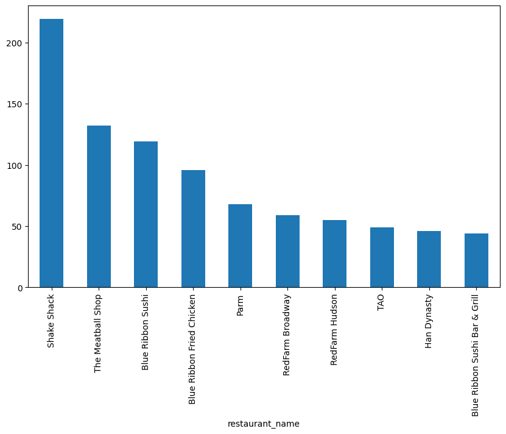

```python
# counts the number of orders for each restaurant and selects the top 10 restaurants
restaurant_name = df["restaurant_name"].value_counts().head(10)

# creates a bar chart to visualize the top 10 restaurants by number of orders
restaurant_name.plot(kind='bar', figsize=(10, 6))

# displays the plot
plt.show()
```

Observations:

There are 178 unique restaurants on the platform.

128 restaurants have received more than one order, indicating that most restaurants have repeat demand.

Shake Shack has the highest number of orders by a large margin.

**Cuisine type**

```python
# calculates the number of unique cuisine types in the dataset
df_unique_ct = df["cuisine_type"].nunique()

# prints the number of unique cuisine types
print(" Number of unique cuisine types: ", df_unique_ct)
```

```
 Number of unique cuisine types:  14
```

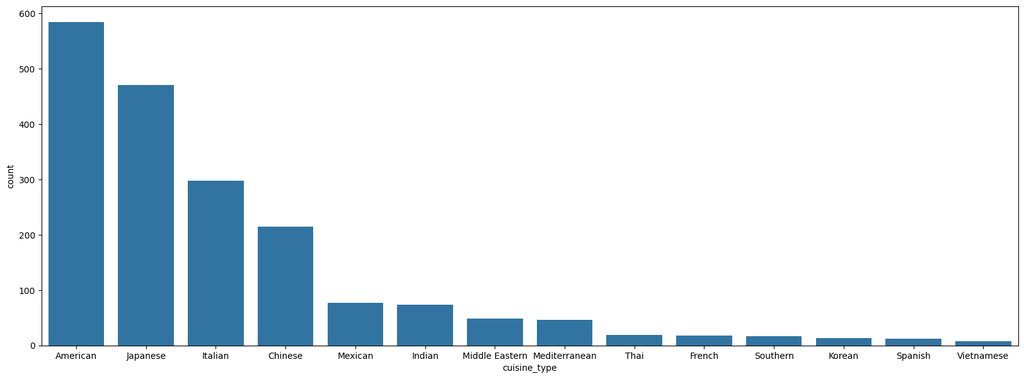

```python
# sets the size of the figure for better readability
plt.figure(figsize=(20, 7))

# creates a count plot showing the number of orders for each cuisine type, ordered by frequency
sns.countplot(data=df, x='cuisine_type', order=df['cuisine_type'].value_counts().index)

# displays the plot
plt.show()
```

Observations:

There are 14 unique cuisine types on the platform.

Customer preferences show a strong skew toward a small set of mainstream cuisines, namely American, Japanese, Italian and Chinese.

The remaining Cuisines form a long tail of less frequently ordered cuisines, suggesting that demand is not evenly distributed across cuisine types.

**Cost of the order**

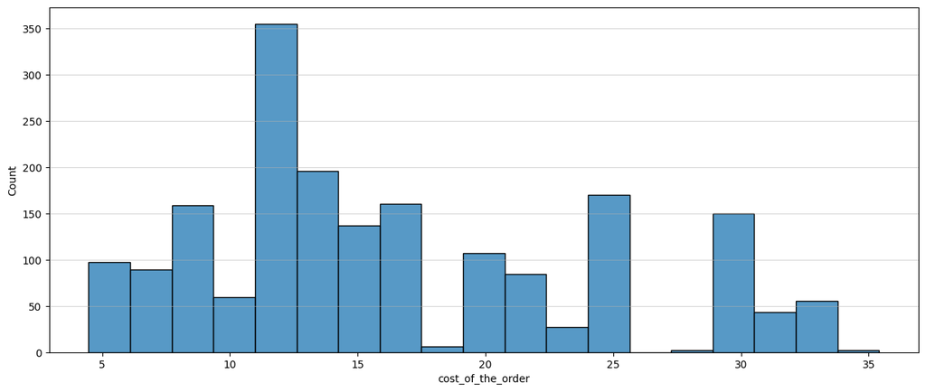

```python
# sets the size of the figure for the histogram
plt.figure(figsize=(15, 6))

# creates a histogram to show the distribution of order costs
sns.histplot(data=df, x="cost_of_the_order")

# adds horizontal grid lines to improve readability
plt.grid(axis='y', alpha=0.5)  # Grid for the histogram

# displays the plot
plt.show()
```

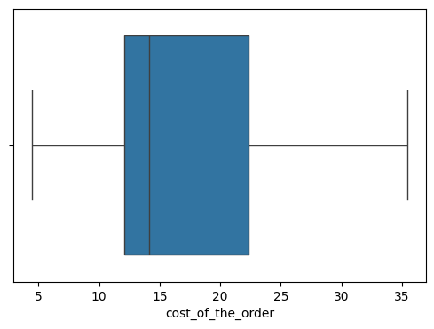

```python
# sets the size of the figure for the boxplot
plt.figure(figsize=(6, 4))

# creates a boxplot to visualize the distribution and outliers of order costs
sns.boxplot(data=df, x="cost_of_the_order")

# displays the plot
plt.show()
```

Observations:

Order prices distribution is not smooth and exhibiting a multimodal distribution. This indicates that prices cluster around distinct price points rather than being evenly spread.

The overall price range (around 5 to 35 dollars) contains no extreme outliers, indicating that all observed prices fall within a consistent and controlled pricing structure.

**Day of the week**

```python
# counts the number of orders placed on each day of the week
df["day_of_the_week"].value_counts()
```

| day_of_the_week | count |
| --- | --- |
| Weekend | 1351 |
| Weekday | 547 |

**dtype:** int64

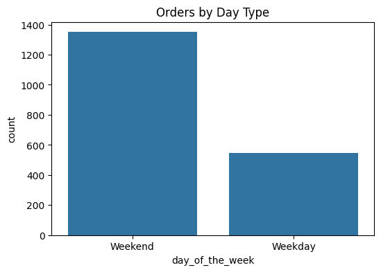

```python
# sets the size of the figure for the plot
plt.figure(figsize=(6, 4))

# creates a count plot to show the number of orders by day of the week
sns.countplot(data=df, x="day_of_the_week")

# adds a title to the plot
plt.title('Orders by Day Type')

# displays the plot
plt.show()
```

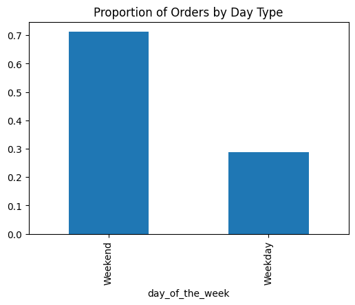

```python
# calculates the proportion of orders for each day of the week
proportions = df['day_of_the_week'].value_counts(normalize=True)

# sets the size of the figure for the plot
plt.figure(figsize=(6, 4))

# creates a bar chart to visualize the proportion of orders by day of the week
proportions.plot(kind='bar')

# adds a title to the plot
plt.title('Proportion of Orders by Day Type')

# displays the plot
plt.show()
```

Observations:

Orders are substantially higher on weekends, 1351, than on weekdays, 547.

Weekend orders account for roughly 70% of total orders, while weekdays account for about 30%.

The large difference in counts indicates that order activity is not evenly distributed across the week, with demand concentrated on weekends.

**Rating**

```python
# counts the frequency of each rating value in the dataset
df["rating"].value_counts()
```

| rating | count |
| --- | --- |
| Not given | 736 |
| 5 | 588 |
| 4 | 386 |
| 3 | 188 |

**dtype:** int64

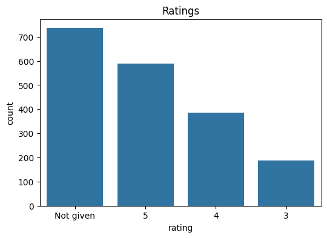

```python
# sets the size of the figure for the plot
plt.figure(figsize=(6, 4))

# creates a count plot showing the frequency of each rating, ordered by count
sns.countplot(data=df, x="rating", order=df["rating"].value_counts().index)

# adds a title to the plot
plt.title("Ratings")

# displays the plot
plt.show()
```

Observations:

A large proportion of orders are not rated (736), making this the most frequent category.

Among the rated orders, higher ratings dominate. 5 star ratings are most common, followed by 4 star, with 3 star ratings being least frequent.

The distribution of given ratings is skewed toward higher values, indicating that when ratings are provided, they tend to be favourable.

The high number of “Not given” entries indicates that ratings data is incomplete, which should be considered in any rating-based analysis.

**Food Preparation time**

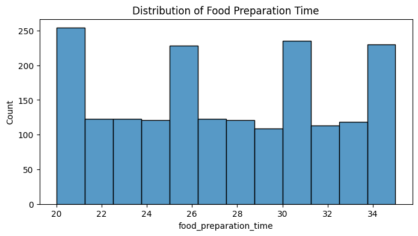

```python
# sets the size of the figure for the histogram
plt.figure(figsize=(8, 4))

# creates a histogram to show the distribution of food preparation time
sns.histplot(data=df, x="food_preparation_time")

# adds a title to the plot
plt.title("Distribution of Food Preparation Time")

# displays the plot
plt.show()
```

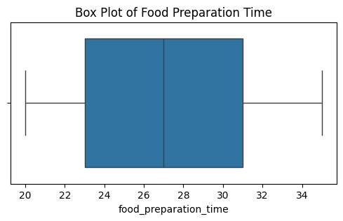

```python
# sets the size of the figure for the boxplot
plt.figure(figsize=(6, 3))

# creates a boxplot to visualize the distribution and outliers of food preparation time
sns.boxplot(data=df, x='food_preparation_time')

# adds a title to the plot
plt.title('Box Plot of Food Preparation Time')

# displays the plot
plt.show()
```

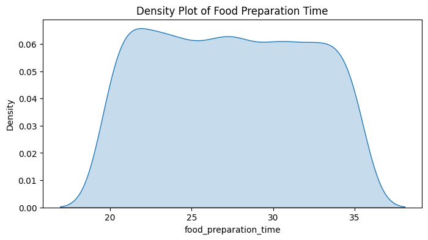

```python
# sets the size of the figure for the density plot
plt.figure(figsize=(8, 4))

# creates a KDE plot to visualize the distribution of food preparation time
sns.kdeplot(data=df, x='food_preparation_time', fill=True)

# adds a title to the plot
plt.title('Density Plot of Food Preparation Time')

# displays the plot
plt.show()
```

Observations:

The preparation time is extremely controlled, spanning a narrow range from the minimum of 20 minutes to the maximum of 35 minutes.

The majority of orders (50%) are prepared between approximately 23 minutes (25th percentile) and 31 minutes (75th percentile).

No outliers are present in the data, confirming the consistency of the preparation process. The median (around 27 minutes) is central within the range, indicating a mostly symmetrical distribution.

he distribution is not smooth or normal. It is highly multimodal and uniform-like, with distinct peaks visible at 20, 26, 31, and 34 minutes.

**Delivery time**

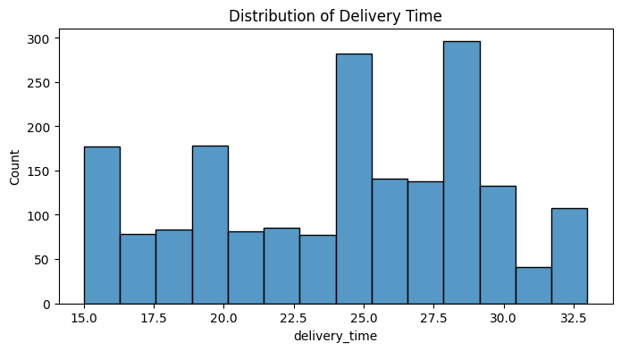

```python
# sets the size of the figure for the histogram
plt.figure(figsize=(8, 4))

# creates a histogram to show the distribution of delivery time
sns.histplot(data=df, x="delivery_time")

# adds a title to the plot
plt.title("Distribution of Delivery Time")

# displays the plot
plt.show()
```

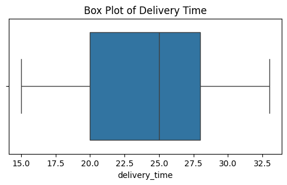

```python
# sets the size of the figure for the boxplot
plt.figure(figsize=(6, 3))

# creates a boxplot to visualize the distribution and outliers of delivery time
sns.boxplot(data=df, x="delivery_time")

# adds a title to the plot
plt.title('Box Plot of Delivery Time')

# displays the plot
plt.show()
```

Observations:

Delivery times range approximately from 15 to 33 minutes, indicating a bounded delivery window.

The central delivery time lies around 25 to 27 minutes, with most deliveries clustered between 20 and 28 minutes. The distribution shows greater spread than food preparation time, indicating more variability in delivery duration.

The boxplot shows no outliers, suggesting that longer delivery times still fall within the normal operating range.

### **Question 7**: Which are the top 5 restaurants in terms of the number of orders received? [1 mark]

```python
df['restaurant_name'].value_counts().head(5)
# counts orders per restaurant and returns the top 5 by number of orders
```

| restaurant_name | count |
| --- | --- |
| Shake Shack | 219 |
| The Meatball Shop | 132 |
| Blue Ribbon Sushi | 119 |
| Blue Ribbon Fried Chicken | 96 |
| Parm | 68 |

**dtype:** int64

#### Observations:

The top 5 restaurants in terms of the number of order are Shake Shack, The Meatball Shop, Blue Ribbon Sushi, Blue Ribbon Fried Chicken and Parm respectively.

### **Question 8**: Which is the most popular cuisine on weekends? [1 mark]

```python
weekends = df['day_of_the_week'] == 'Weekend' # Filters orders placed on weekends
df[weekends]['cuisine_type'].value_counts() # Counts orders by cuisine type and returns the most to least popular cuisine on weekends
```

| cuisine_type | count |
| --- | --- |
| American | 415 |
| Japanese | 335 |
| Italian | 207 |
| Chinese | 163 |
| Mexican | 53 |
| Indian | 49 |
| Middle Eastern | 32 |
| Mediterranean | 32 |
| Thai | 15 |
| French | 13 |
| Korean | 11 |
| Southern | 11 |
| Spanish | 11 |
| Vietnamese | 4 |

**dtype:** int64

#### Observations:

The most popular cuisine on the weekends is American

### **Question 9**: What percentage of the orders cost more than 20 dollars? [2 marks]

```python
(df["cost_of_the_order"]>20).mean()*100 # > 20 creates a True/False mask
# mean() gives the proportion of True
# * 100 converts it to a percentage
```

```
np.float64(29.24130663856691)
```

#### Observations:

The percentage of the orders that cost more than 20 dollars is 29.24%

### **Question 10**: What is the mean order delivery time? [1 mark]

```python
(df['delivery_time']).mean()
# using mean() to calculate the average time for order delivery
```

```
np.float64(24.161749209694417)
```

#### Observations:

The mean order delivery time is 24.16 minutes.

### **Question 11:** The company has decided to give 20% discount vouchers to the top 3 most frequent customers. Find the IDs of these customers and the number of orders they placed. [1 mark]

```python
df['customer_id'].value_counts().head(3) # using value_counts to find the number of orders each of them placed
# using head() to find the top 3 most frequent customers (their IDs)
```

| customer_id | count |
| --- | --- |
| 52832 | 13 |
| 47440 | 10 |
| 83287 | 9 |

**dtype:** int64

#### Observations:

The top 3 most frequent customer IDs are 52832, 47440 and 83287 respectively.

### **Question 12**: Perform a multivariate analysis to explore relationships between the important variables in the dataset. (It is a good idea to explore relations between numerical variables as well as relations between numerical and categorical variables) [10 marks]

**Correlation among Numerial Variables**

**Correlation heatmap among all the variables**

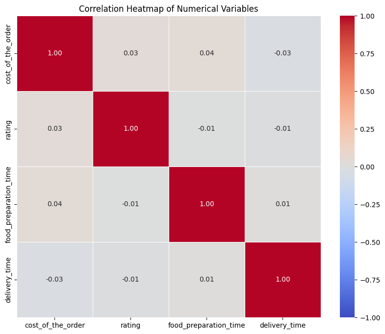

```python
# Replace 'Not given' with NaN in the 'rating' column
df_numeric = df.copy()
df_numeric['rating'] = df_numeric['rating'].replace('Not given', np.nan)
# Convert the 'rating' column to numeric
df_numeric['rating'] = pd.to_numeric(df_numeric['rating'])

# Select only numerical columns for correlation analysis, excluding 'order_id' and 'customer_id'
numerical_cols = df_numeric.select_dtypes(include=np.number).columns.drop(['order_id', 'customer_id']).tolist()

# Calculate the correlation matrix
corr_matrix = df_numeric[numerical_cols].corr()

# Plotting the heatmap
plt.figure(figsize=(10, 8))
sns.heatmap(corr_matrix, annot=True,vmin=-1, vmax=1, cmap='coolwarm', fmt=".2f", linewidths=.5)
plt.title('Correlation Heatmap of Numerical Variables')
plt.show()
```

#### Observation:

Cost of the order shows very weak or no correlation with delivery time, suggesting higher-priced orders are not necessarily delivered slower.

**Correlation among Numerial and Categorical Variables**

**Delivery time by Day of the week**

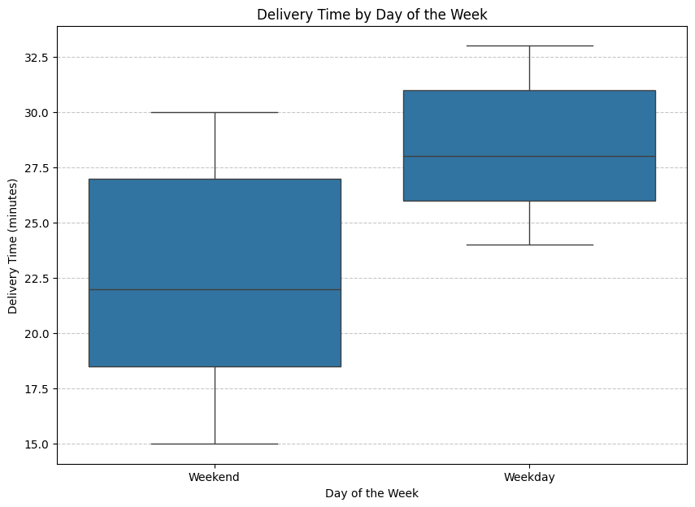

```python
# sets the size of the figure for the boxplot
plt.figure(figsize=(10, 7))

# creates a boxplot to compare delivery time across different days of the week
sns.boxplot(x='day_of_the_week', y='delivery_time', data=df)

# adds a title to the plot
plt.title('Delivery Time by Day of the Week')

# labels the x-axis
plt.xlabel('Day of the Week')

# labels the y-axis
plt.ylabel('Delivery Time (minutes)')

# adds horizontal grid lines to improve readability
plt.grid(axis='y', linestyle='--', alpha=0.7)

# displays the plot
plt.show()
```

#### Observation:

**Cost of the order by Day of the Week**

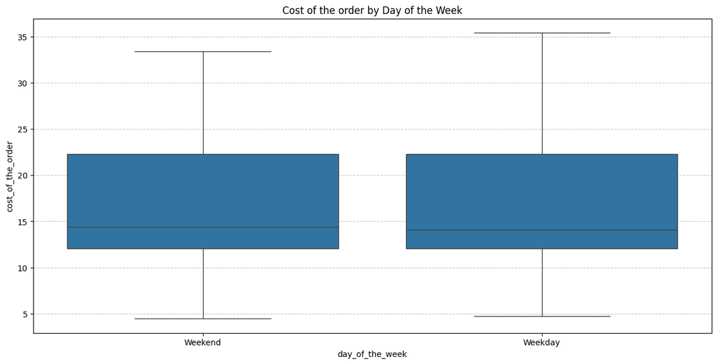

```python
# sets the size of the figure for the boxplot
plt.figure(figsize=(15, 7))

# creates a boxplot to compare order cost across different days of the week
sns.boxplot(x='day_of_the_week', y='cost_of_the_order', data=df)

# adds a title to the plot
plt.title('Cost of the order by Day of the Week')

# adds horizontal grid lines to improve readability
plt.grid(axis='y', linestyle='--', alpha=0.7)

# displays the plot
plt.show()
```

#### Observation

The typical (median) cost is very similar on weekdays vs weekends (median 14.07 weekday vs 14.41 weekend).

**Food preparation time by Day of the Week**

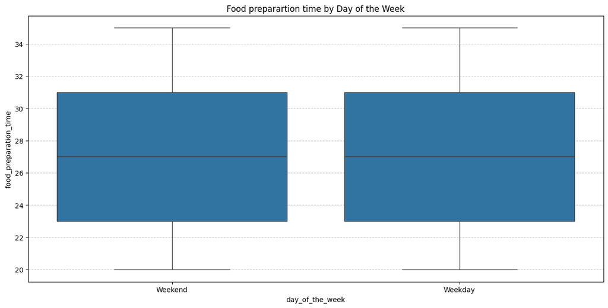

```python
# sets the size of the figure for the boxplot
plt.figure(figsize=(15, 7))

# creates a boxplot to compare food preparation time across different days of the week
sns.boxplot(x='day_of_the_week', y='food_preparation_time', data=df)

# adds a title to the plot
plt.title('Food preparartion time by Day of the Week')

# adds horizontal grid lines to improve readability
plt.grid(axis='y', linestyle='--', alpha=0.7)

# displays the plot
plt.show()
```

#### Observation

Preparation time distributions are almost identical for weekdays and weekends (median about 27 mins for both).

This suggests the big weekday/weekend difference seen earlier is driven more by deliverylogistics, not food preparation.

**Ratings by Day of the Week**

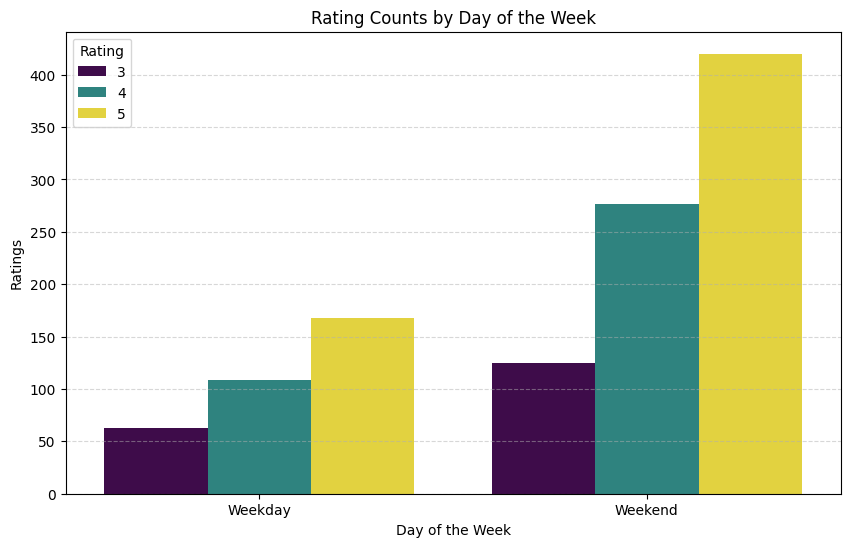

```python
# Remove 'Not given' ratings and convert rating to numeric
df_ratings = df[df['rating'] != 'Not given'].copy()
df_ratings['rating'] = df_ratings['rating'].astype(int)

# sets the size of the figure for the count plot
plt.figure(figsize=(10, 6))

# creates a count plot showing rating frequencies for each day of the week
sns.countplot(x='day_of_the_week', hue='rating', data=df_ratings, palette='viridis')

# adds a title to the plot
plt.title('Rating Counts by Day of the Week')

# labels the x-axis
plt.xlabel('Day of the Week')

# labels the y-axis
plt.ylabel('Ratings')

# displays the legend with a title
plt.legend(title='Rating')

# adds horizontal grid lines to improve readability
plt.grid(axis='y', linestyle='--', alpha=0.5)

# displays the plot
plt.show()
```

#### Observation:

Weekend orders show a slightly higher frequency of good ratings, aligning with faster average delivery times observed on weekends.

5-star ratings dominate on both weekday and weekend. Weekend has a slightly higher share of 5-star ratings (about 51.1% weekend vs 49.4% weekday among rated orders).

Weekdays have a higher share of 3-star ratings (≈ 18.5% weekday vs 15.2% weekend), indicating slightly worse experiences on weekdays.

**Ratings vs Cuisines**

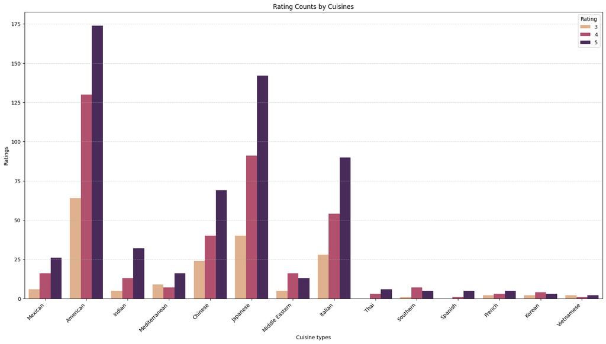

```python
# Remove 'Not given' ratings and convert rating to numeric
df_ratings = df[df['rating'] != 'Not given'].copy()
df_ratings['rating'] = df_ratings['rating'].astype(int)

# sets the size of the figure for the count plot
plt.figure(figsize=(20, 10))

# creates a count plot showing rating frequencies for each cuisine type
sns.countplot(x='cuisine_type', hue='rating', data=df_ratings, palette="flare")

# adds a title to the plot
plt.title('Rating Counts by Cuisines')

# labels the x-axis
plt.xlabel('Cuisine types')

# labels the y-axis
plt.ylabel('Ratings')

# displays the legend with a title
plt.legend(title='Rating')

# adds horizontal grid lines to improve readability
plt.grid(axis='y', linestyle='--', alpha=0.5)

# rotates x-axis labels for better readability
plt.xticks(rotation=45, ha='right')

# displays the plot
plt.show()
```

#### Observation:

Most cuisines are dominated by ratings 4 and 5, with 5 generally the most frequent.

High-volume cuisines like American, Japanese, Italian, Chinese show lots of ratings across 3/4/5 — meaning they drive most of the rating patterns overall.

Some cuisines show very high 5-star share (e.g., Spanish, Thai, Indian) but these categories have low rating counts, so they’re less reliable for strong conclusions.

**Delivery time by Cuisines**

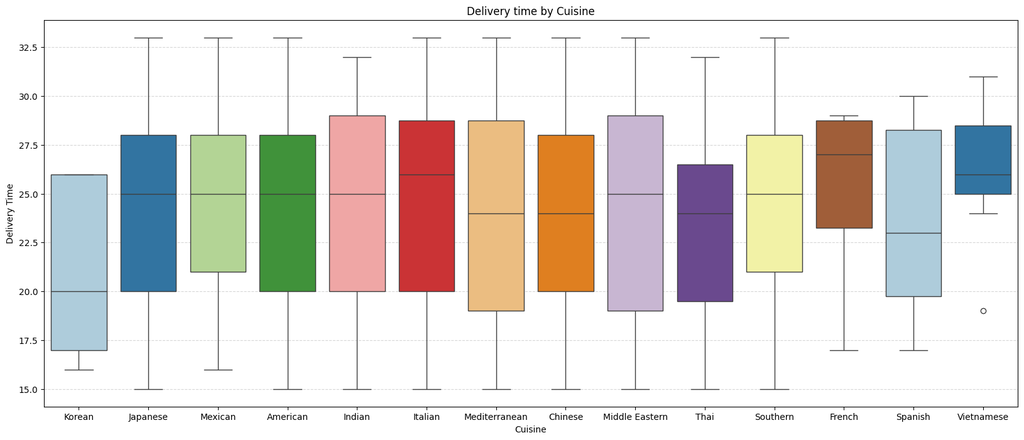

```python
# sets the size of the figure for the boxplot
plt.figure(figsize=(20, 8))

# creates a boxplot to compare delivery time across different cuisine types
sns.boxplot(x='cuisine_type', y='delivery_time', data=df, hue='cuisine_type', palette='Paired')

# adds a title to the plot
plt.title('Delivery time by Cuisine')

# labels the x-axis
plt.xlabel('Cuisine')

# labels the y-axis
plt.ylabel('Delivery Time')

# adds horizontal grid lines to improve readability
plt.grid(axis='y', linestyle='--', alpha=0.5)

# displays the plot
plt.show()
```

#### Observation

Delivery times vary across cuisines, but no cuisine consistently shows extreme delays, suggesting operational efficiency is relatively uniform across restaurant types.

Median delivery time is similar across most cuisines (generally around the mid-20s).

No cuisine stands out as consistently extreme, though some low-sample cuisines show more visible variation.

**Cuisines vs Cost of the order**

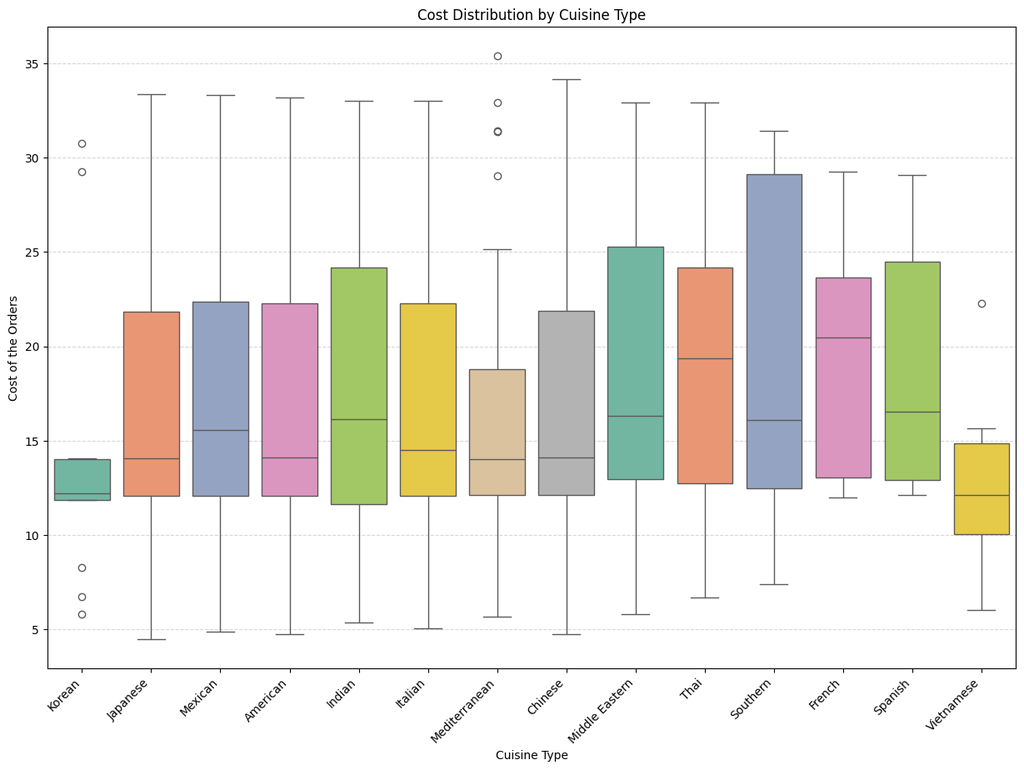

```python
# sets the size of the figure for the boxplot
plt.figure(figsize=(15, 10))

# creates a boxplot to compare order cost across different cuisine types
sns.boxplot(x="cuisine_type", y="cost_of_the_order", data=df, palette='Set2')

# adds a title to the plot
plt.title('Cost Distribution by Cuisine Type')

# labels the x-axis
plt.xlabel('Cuisine Type')

# labels the y-axis
plt.ylabel('Cost of the Orders')

# rotates x-axis labels for better readability
plt.xticks(rotation=45, ha='right')

# adds horizontal grid lines to improve readability
plt.grid(axis='y', linestyle='--', alpha=0.5)

# displays the plot
plt.show()
```

#### Observation:

Cost distributions differ by cuisine: some cuisines have higher typical order costs (e.g., French/Thai/Southern/Middle Eastern tend to sit higher on median/upper ranges).

High-volume cuisines (American/Japanese/Italian/Chinese) show wide ranges, meaning they include both low and high cost orders.

**Cuisines vs Food preparation time**

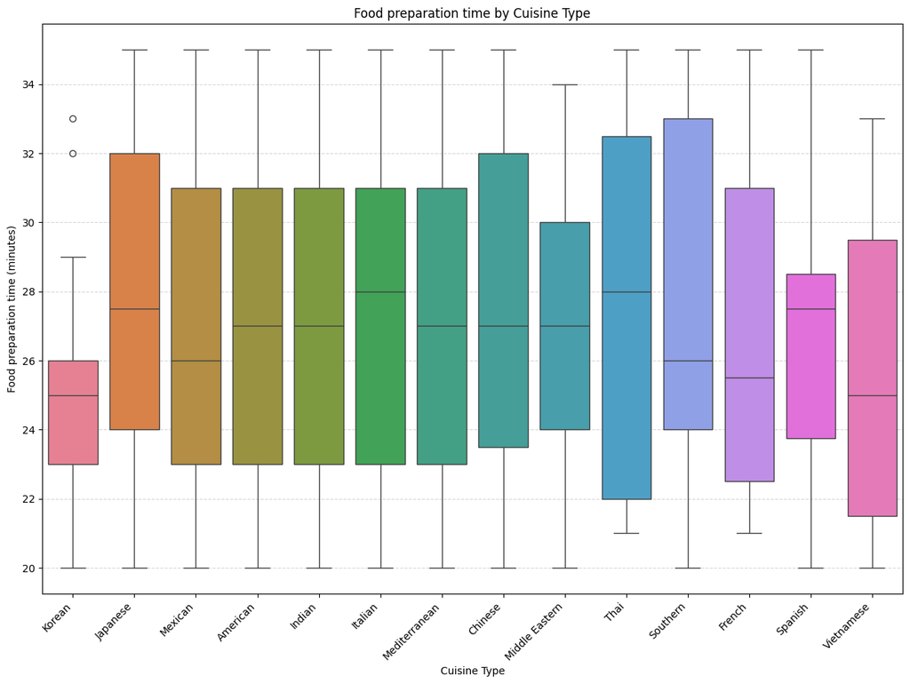

```python
# sets the size of the figure for the boxplot
plt.figure(figsize=(15, 10))

# creates a boxplot to compare food preparation time across different cuisine types
sns.boxplot(x="cuisine_type", y="food_preparation_time", data=df, palette='husl')

# adds a title to the plot
plt.title('Food preparation time by Cuisine Type')

# labels the x-axis
plt.xlabel('Cuisine Type')

# labels the y-axis
plt.ylabel('Food preparation time (minutes)')

# rotates x-axis labels for better readability
plt.xticks(rotation=45, ha='right')

# adds horizontal grid lines to improve readability
plt.grid(axis='y', linestyle='--', alpha=0.5)

# displays the plot
plt.show()
```

#### Observation:

Prep time is broadly consistent across cuisines (most medians around ~26 to 28 mins).

A few cuisines show slightly lower typical prep times (e.g., Korean/Vietnamese), but they also have much smaller counts, so the box shapes can be less stable.

**Revenue generated by restaurants (top 15)**

```python
# groups the data by restaurant name, calculates the total order cost for each restaurant, sorts it in descending order, and returns the top 15 restaurants by total revenue
df.groupby(['restaurant_name'])['cost_of_the_order'].sum().sort_values(ascending = False).head(15)
```

| restaurant_name | cost_of_the_order |
| --- | --- |
| Shake Shack | 3579.53 |
| The Meatball Shop | 2145.21 |
| Blue Ribbon Sushi | 1903.95 |
| Blue Ribbon Fried Chicken | 1662.29 |
| Parm | 1112.76 |
| RedFarm Broadway | 965.13 |
| RedFarm Hudson | 921.21 |
| TAO | 834.50 |
| Han Dynasty | 755.29 |
| Blue Ribbon Sushi Bar & Grill | 666.62 |
| Rubirosa | 660.45 |
| Sushi of Gari 46 | 640.87 |
| Nobu Next Door | 623.67 |
| Five Guys Burgers and Fries | 506.47 |
| Momoya | 492.13 |

**dtype:** float64

#### Observations from Revenue Generated by Restaurants:

Dominant Leader: Shake Shack is by far the highest revenue-generating restaurant, bringing in 3579.53 dollars, which is significantly more than the second-highest 'The Meatball Shop' at 2145.21 dollars.

Concentrated Revenue: The top few restaurants account for a substantial portion of the total revenue. The top 5 alone contribute a significant amount.

Steep Drop-off: There's a clear and steep decline in revenue as you move down the list of restaurants, indicating that a relatively small number of partners drive the majority of the company's earnings from restaurants.

Consistency: This revenue performance aligns well with earlier observations about Shake Shack being the restaurant with the highest number of orders, confirming its overall popularity and financial impact.

### **Question 13:** The company wants to provide a promotional offer in the advertisement of the restaurants. The condition to get the offer is that the restaurants must have a rating count of more than 50 and the average rating should be greater than 4. Find the restaurants fulfilling the criteria to get the promotional offer. [3 marks]

```python
# Remove 'Not given' ratings and convert rating to numeric
df_ratings = df[df['rating'] != 'Not given'].copy()
df_ratings['rating'] = df_ratings['rating'].astype(int)

# Group by restaurant and compute count and mean rating
restaurant_stats = df_ratings.groupby('restaurant_name')['rating'].agg(
    rating_count='count',
    avg_rating='mean')

# Apply the conditions
eligible_restaurants = restaurant_stats[
    (restaurant_stats['rating_count'] > 50) &
    (restaurant_stats['avg_rating'] > 4)].sort_values(by='rating_count', ascending=False)

eligible_restaurants
```

| restaurant_name | rating_count | avg_rating |
| --- | --- | --- |
| Shake Shack | 133 | 4.278195 |
| The Meatball Shop | 84 | 4.511905 |
| Blue Ribbon Sushi | 73 | 4.219178 |
| Blue Ribbon Fried Chicken | 64 | 4.328125 |

#### Observations:

Four restaurants meet the promotional criteria of more than 50 ratings and an average rating above 4.

Shake Shack has the highest number of ratings (133), indicating strong customer engagement.

The Meatball Shop has the highest average rating (4.51) among eligible restaurants. All selected restaurants have consistently high average ratings (above 4.2), with substantial rating volumes.

These restaurants demonstrate both high customer satisfaction and sufficient rating volume, making them reliable and suitable candidates for the promotional offer.

### **Question 14:** The company charges the restaurant 25% on the orders having cost greater than 20 dollars and 15% on the orders having cost greater than 5 dollars. Find the net revenue generated by the company across all orders. [3 marks]

```python
# Calculate commission per order
df['company_revenue'] = np.where(
    df['cost_of_the_order'] > 20,
    df['cost_of_the_order'] * 0.25,
    np.where(
        df['cost_of_the_order'] > 5,
        df['cost_of_the_order'] * 0.15,
        0
    )
)

# Total net revenue
net_revenue = df['company_revenue'].sum()

print('The net revenue is around', round(net_revenue, 2), 'dollars')
```

```
The net revenue is around 6166.3 dollars
```

#### Observations:

The net revenue generated by the company across all orders is around 6166.30 dollars

### **Question 15:** The company wants to analyze the total time required to deliver the food. What percentage of orders take more than 60 minutes to get delivered from the time the order is placed? (The food has to be prepared and then delivered.) [2 marks]

```python
# Total delivery time = preparation time + delivery time
total_time = df['food_preparation_time'] + df['delivery_time']

# Percentage of orders taking more than 60 minutes
percentage_over_60 = (total_time > 60).mean() * 100

print(round(percentage_over_60,2))
```

```
10.54
```

#### Observations:

Around 10.54% of orders take more than 60 minutes to be prepared and delivered.

### **Question 16:** The company wants to analyze the delivery time of the orders on weekdays and weekends. How does the mean delivery time vary during weekdays and weekends? [2 marks]

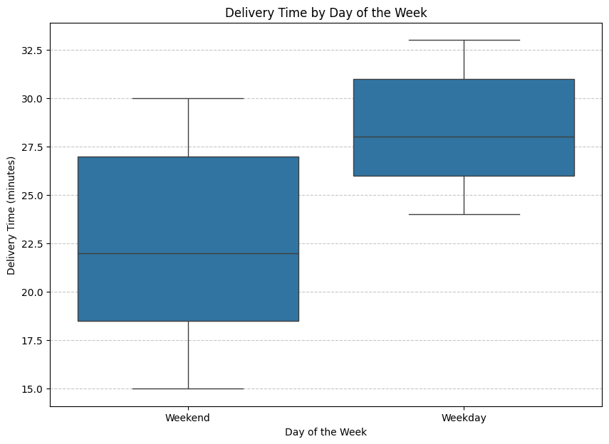

```python
# sets the size of the figure for the boxplot
plt.figure(figsize=(10, 7))

# creates a boxplot to compare delivery time across different days of the week
sns.boxplot(x='day_of_the_week', y='delivery_time', data=df)

# adds a title to the plot
plt.title('Delivery Time by Day of the Week')

# labels the x-axis
plt.xlabel('Day of the Week')

# labels the y-axis
plt.ylabel('Delivery Time (minutes)')

# adds horizontal grid lines to improve readability
plt.grid(axis='y', linestyle='--', alpha=0.7)

# displays the plot
plt.show()
```

```python
# groups the data by day of the week and calculates the mean delivery time for each day
df.groupby('day_of_the_week')['delivery_time'].mean()
```

| day_of_the_week | delivery_time |
| --- | --- |
| Weekday | 28.340037 |
| Weekend | 22.470022 |

**dtype:** float64

#### Observations:

The mean delivery time is higher on weekdays (about 28.34 minutes) compared to weekends (about 22.47 minutes).

This indicates that deliveries take, on average, about 6 minutes longer on weekdays than on weekends.

The boxplot supports this difference, showing higher central values and overall distribution for weekday delivery times compared to weekends.